# Исследование объявлений о продаже квартир

Посмотрим, как обстоят дела с датами размещения объявлений.

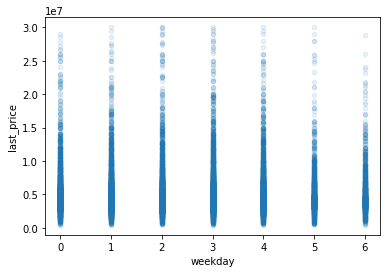

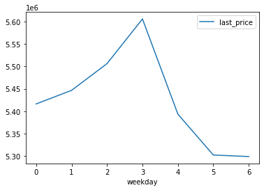

```python
data.plot(x='weekday', y='last_price', kind='scatter', alpha=0.1)
data.pivot_table(index='weekday', values='last_price').plot()
```

Судя по этим графикам, средняя стоимость квартир, выставленных на продажу в четверг значительно превышает среднюю стоимость квартир, выставленных на продажу в любой другой день. Для выходных ситуация обратная--выставленные на продажу в эти дни квартиры в среднем дешевле, чем остальные. Однако, стоит обратить внимание, что разница между максимальным значением (четверг) и минимальным значением (воскресенье) составляет 300 000 рублей, а это примерно 5,4%.

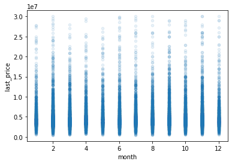

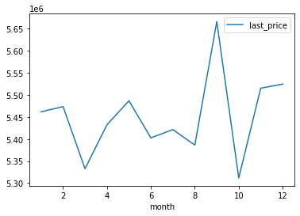

```python
data.plot(x='month', y='last_price', kind='scatter', alpha=0.1)
data.pivot_table(index='month', values='last_price').plot()
```

С месяцами ситуация похожая: в сентябре цены на квартиры в среднем значительно выше, чем в другие месяцы, а в марте и октябре -- наоборот. Разница между максимальным и минимальным значениями всё ещё небольшая: 350 000 рублей или 6,2%.

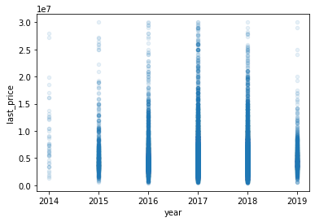

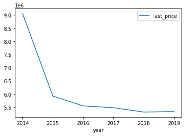

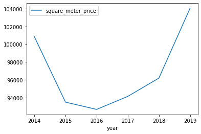

```python
data.plot(x='year', y='last_price', kind='scatter', alpha=0.1)
data.pivot_table(index='year', values='last_price').plot()
data.pivot_table(index='year', values='square_meter_price').plot()
```

Тут график выглядит странно, для начала посмотрим, сколько квартир было выставлено на продажу в 2014, возможно, стоит убрать их из таблицы, чтобы нагляднее увидеть, как обстоят дела с основным массивом данных.

```python
data.query('year==2014')
```

|  | index | total_images | last_price | total_area | first_day_exposition | rooms | ceiling_height | floors_total | living_area | floor | is_apartment | studio | open_plan | kitchen_area | balcony | locality_name | airports_nearest | city_centers_nearest | parks_around3000 | parks_nearest | ponds_around3000 | ponds_nearest | days_exposition | locality_only_name | square_meter_price | weekday | month | year | floor_type |
| --- | --- | --- | --- | --- | --- | --- | --- | --- | --- | --- | --- | --- | --- | --- | --- | --- | --- | --- | --- | --- | --- | --- | --- | --- | --- | --- | --- | --- | --- |
| 396 | 412 | 7 | 6800000.0 | 90.00 | 2014-12-16 | 3.0 | 2.60 | 9.0 | 43.30 | 1 | False | False | False | 25.00 | 0.0 | Санкт-Петербург | 35151.0 | 12.0 | 0.0 | 459.0 | 1.0 | 837.0 | 608.0 | Санкт-Петербург | 75555.555556 | 1 | 12 | 2014 | первый |
| 457 | 475 | 1 | 12036000.0 | 100.00 | 2014-11-27 | 3.0 | 2.65 | 16.0 | 52.00 | 3 | False | False | False | 11.00 | 1.0 | Санкт-Петербург | 37407.0 | 8.0 | 1.0 | 456.0 | 2.0 | 454.0 | 606.0 | Санкт-Петербург | 120360.000000 | 3 | 11 | 2014 | другой |
| 483 | 501 | 0 | 27250000.0 | 169.00 | 2014-12-09 | 5.0 | 2.65 | 12.0 | 89.00 | 9 | False | False | False | 22.00 | 1.0 | Санкт-Петербург | 19008.0 | 4.0 | 0.0 | 459.0 | 1.0 | 69.0 | 594.0 | Санкт-Петербург | 161242.603550 | 1 | 12 | 2014 | другой |
| 514 | 534 | 1 | 3364930.0 | 34.69 | 2014-11-27 | 1.0 | 2.64 | 25.0 | 23.43 | 25 | False | False | False | 23.43 | 2.0 | Санкт-Петербург | 43396.0 | 12.0 | 0.0 | 459.0 | 0.0 | 510.0 | 574.0 | Санкт-Петербург | 97000.000000 | 3 | 11 | 2014 | последний |
| 650 | 681 | 20 | 19800000.0 | 139.80 | 2014-12-09 | 4.0 | 3.40 | 3.0 | 93.50 | 3 | False | False | False | 18.80 | 0.0 | Санкт-Петербург | 24011.0 | 5.0 | 1.0 | 336.0 | 0.0 | 510.0 | 637.0 | Санкт-Петербург | 141630.901288 | 1 | 12 | 2014 | последний |
| 1085 | 1128 | 17 | 13800000.0 | 103.00 | 2014-12-15 | 3.0 | 2.80 | 9.0 | 56.00 | 7 | False | False | False | 13.20 | 2.0 | Санкт-Петербург | 36276.0 | 11.0 | 0.0 | 459.0 | 0.0 | 510.0 | 554.0 | Санкт-Петербург | 133980.582524 | 0 | 12 | 2014 | другой |
| 1509 | 1570 | 0 | 1300000.0 | 52.70 | 2014-12-05 | 3.0 | 2.65 | 5.0 | 39.40 | 1 | False | False | False | 6.70 | 0.0 | Подпорожье | 200000.0 | 70.0 | 0.0 | 3100.0 | 0.0 | 3100.0 | 581.0 | Подпорожье | 24667.931689 | 4 | 12 | 2014 | первый |
| 2330 | 2421 | 20 | 3390000.0 | 42.20 | 2014-12-19 | 1.0 | 2.65 | 16.0 | 17.50 | 10 | False | False | False | 10.00 | 2.0 | Санкт-Петербург | 18449.0 | 22.0 | 0.0 | 459.0 | 2.0 | 922.0 | 690.0 | Санкт-Петербург | 80331.753555 | 4 | 12 | 2014 | другой |
| 2669 | 2775 | 0 | 12738000.0 | 124.00 | 2014-12-09 | 4.0 | 2.65 | 15.0 | 62.00 | 10 | False | False | False | 24.00 | 1.0 | Санкт-Петербург | 19160.0 | 4.0 | 0.0 | 459.0 | 1.0 | 852.0 | 594.0 | Санкт-Петербург | 102725.806452 | 1 | 12 | 2014 | другой |
| 2881 | 2994 | 1 | 12561120.0 | 93.60 | 2014-11-27 | 3.0 | 3.00 | 16.0 | 52.00 | 5 | False | False | False | 10.90 | 2.0 | Санкт-Петербург | 37407.0 | 8.0 | 1.0 | 456.0 | 2.0 | 454.0 | 583.0 | Санкт-Петербург | 134200.000000 | 3 | 11 | 2014 | другой |
| 3123 | 3249 | 9 | 17000000.0 | 156.00 | 2014-12-12 | 4.0 | 3.50 | 5.0 | 115.00 | 5 | False | False | False | 41.00 | 2.0 | Санкт-Петербург | 24253.0 | 5.0 | 1.0 | 694.0 | 1.0 | 650.0 | 692.0 | Санкт-Петербург | 108974.358974 | 4 | 12 | 2014 | последний |
| 3324 | 3456 | 10 | 9990000.0 | 95.00 | 2014-12-11 | 3.0 | 2.65 | 4.0 | 73.00 | 3 | False | False | False | 8.00 | 1.0 | Санкт-Петербург | 24380.0 | 4.0 | 0.0 | 459.0 | 1.0 | 636.0 | 561.0 | Санкт-Петербург | 105157.894737 | 3 | 12 | 2014 | другой |
| 3331 | 3463 | 9 | 5320000.0 | 50.10 | 2014-12-09 | 2.0 | 2.65 | 9.0 | 30.40 | 4 | False | False | False | 9.00 | 0.0 | Санкт-Петербург | 13404.0 | 16.0 | 0.0 | 459.0 | 1.0 | 789.0 | 561.0 | Санкт-Петербург | 106187.624750 | 1 | 12 | 2014 | другой |
| 3498 | 3636 | 1 | 27933600.0 | 180.80 | 2014-11-27 | 4.0 | 3.10 | 16.0 | 94.89 | 11 | False | False | False | 20.16 | 0.0 | Санкт-Петербург | 37407.0 | 8.0 | 1.0 | 456.0 | 2.0 | 454.0 | 586.0 | Санкт-Петербург | 154500.000000 | 3 | 11 | 2014 | другой |
| 3698 | 3841 | 13 | 18500000.0 | 140.00 | 2014-12-11 | 4.0 | 2.65 | 16.0 | 78.00 | 12 | False | False | False | 17.00 | 0.0 | Санкт-Петербург | 40368.0 | 12.0 | 2.0 | 159.0 | 0.0 | 510.0 | 752.0 | Санкт-Петербург | 132142.857143 | 3 | 12 | 2014 | другой |
| 3815 | 3961 | 2 | 2750000.0 | 41.00 | 2014-12-08 | 1.0 | 2.50 | 10.0 | 20.00 | 7 | False | False | False | 10.00 | 0.0 | Коммунар | 200000.0 | 70.0 | 0.0 | 3100.0 | 0.0 | 3100.0 | 562.0 | Коммунар | 67073.170732 | 0 | 12 | 2014 | другой |
| 4227 | 4382 | 1 | 1700000.0 | 44.70 | 2014-12-08 | 2.0 | 2.55 | 5.0 | 28.00 | 2 | False | False | False | 6.00 | 0.0 | поселок Красная Долина | 200000.0 | 70.0 | 0.0 | 3100.0 | 0.0 | 3100.0 | 581.0 | Красная Долина | 38031.319911 | 0 | 12 | 2014 | другой |
| 4445 | 4605 | 1 | 8585256.0 | 60.40 | 2014-12-09 | 2.0 | 3.10 | 16.0 | 32.04 | 7 | False | False | False | 10.91 | 0.0 | Санкт-Петербург | 37407.0 | 8.0 | 1.0 | 456.0 | 2.0 | 454.0 | 574.0 | Санкт-Петербург | 142140.000000 | 1 | 12 | 2014 | другой |
| 4509 | 4670 | 7 | 3500000.0 | 54.20 | 2014-12-11 | 3.0 | 2.65 | 5.0 | 39.60 | 3 | False | False | False | 7.00 | 0.0 | Колпино | 24119.0 | 30.0 | 1.0 | 729.0 | 0.0 | 505.0 | 574.0 | Колпино | 64575.645756 | 3 | 12 | 2014 | другой |
| 5589 | 5793 | 9 | 5900000.0 | 75.50 | 2014-12-27 | 2.0 | 2.95 | 5.0 | 47.40 | 5 | False | False | False | 12.20 | 0.0 | Санкт-Петербург | 32590.0 | 5.0 | 0.0 | 459.0 | 0.0 | 510.0 | 756.0 | Санкт-Петербург | 78145.695364 | 5 | 12 | 2014 | последний |
| 5987 | 6206 | 6 | 4600000.0 | 39.60 | 2014-12-14 | 1.0 | 2.75 | 14.0 | 21.00 | 8 | False | False | False | 10.00 | 2.0 | Санкт-Петербург | 41570.0 | 12.0 | 1.0 | 493.0 | 0.0 | 510.0 | 649.0 | Санкт-Петербург | 116161.616162 | 6 | 12 | 2014 | другой |
| 6553 | 6786 | 10 | 7300000.0 | 69.00 | 2014-12-10 | 3.0 | 3.20 | 2.0 | 42.30 | 1 | False | False | False | 10.00 | 0.0 | Петергоф | 34799.0 | 30.0 | 3.0 | 174.0 | 3.0 | 326.0 | 573.0 | Петергоф | 105797.101449 | 2 | 12 | 2014 | первый |
| 7231 | 7483 | 9 | 7580000.0 | 84.23 | 2014-12-14 | 3.0 | 2.70 | 25.0 | 43.63 | 20 | False | False | False | 13.41 | 2.0 | Санкт-Петербург | 35847.0 | 16.0 | 0.0 | 459.0 | 0.0 | 510.0 | 718.0 | Санкт-Петербург | 89991.689422 | 6 | 12 | 2014 | другой |
| 7473 | 7731 | 2 | 16137000.0 | 154.76 | 2014-11-27 | 4.0 | 2.70 | 20.0 | 67.81 | 20 | False | False | False | 32.55 | 0.0 | Санкт-Петербург | 18490.0 | 17.0 | 0.0 | 459.0 | 2.0 | 113.0 | 573.0 | Санкт-Петербург | 104271.129491 | 3 | 11 | 2014 | последний |
| 7936 | 8214 | 9 | 2350000.0 | 75.00 | 2014-12-11 | 3.0 | 2.55 | 5.0 | 50.00 | 4 | False | False | False | 8.70 | 0.0 | Светогорск | 200000.0 | 70.0 | 0.0 | 3100.0 | 0.0 | 3100.0 | 607.0 | Светогорск | 31333.333333 | 3 | 12 | 2014 | другой |
| 8670 | 8985 | 5 | 9100000.0 | 80.00 | 2014-12-24 | 3.0 | 3.00 | 5.0 | 54.70 | 4 | False | False | False | 9.10 | 3.0 | Санкт-Петербург | 38838.0 | 8.0 | 0.0 | 459.0 | 1.0 | 757.0 | 573.0 | Санкт-Петербург | 113750.000000 | 2 | 12 | 2014 | другой |
| 8744 | 9063 | 7 | 13200000.0 | 96.70 | 2014-12-22 | 3.0 | 2.65 | 25.0 | 53.00 | 10 | False | False | False | 16.00 | 0.0 | Санкт-Петербург | 36614.0 | 12.0 | 0.0 | 459.0 | 1.0 | 699.0 | 626.0 | Санкт-Петербург | 136504.653568 | 0 | 12 | 2014 | другой |
| 8910 | 9239 | 9 | 4050000.0 | 44.30 | 2014-12-09 | 2.0 | 2.50 | 5.0 | 28.50 | 5 | False | False | False | 5.30 | 0.0 | Санкт-Петербург | 12623.0 | 11.0 | 0.0 | 459.0 | 1.0 | 874.0 | 590.0 | Санкт-Петербург | 91422.121896 | 1 | 12 | 2014 | последний |
| 8951 | 9281 | 14 | 9000000.0 | 95.00 | 2014-12-15 | 4.0 | 3.00 | 4.0 | 62.00 | 4 | False | False | False | 15.50 | 0.0 | Санкт-Петербург | 24372.0 | 4.0 | 0.0 | 459.0 | 0.0 | 510.0 | 575.0 | Санкт-Петербург | 94736.842105 | 0 | 12 | 2014 | последний |
| 9068 | 9404 | 1 | 6051250.0 | 47.00 | 2014-12-09 | 1.0 | 3.10 | 16.0 | 18.95 | 12 | False | False | False | 13.60 | 0.0 | Санкт-Петербург | 37407.0 | 8.0 | 1.0 | 456.0 | 2.0 | 454.0 | 574.0 | Санкт-Петербург | 128750.000000 | 1 | 12 | 2014 | другой |
| 9394 | 9740 | 2 | 7265000.0 | 82.57 | 2014-12-19 | 3.0 | 2.65 | 24.0 | 46.40 | 22 | False | False | False | 10.56 | 4.0 | Санкт-Петербург | 44662.0 | 10.0 | 0.0 | 459.0 | 0.0 | 510.0 | 594.0 | Санкт-Петербург | 87985.951314 | 4 | 12 | 2014 | другой |
| 11919 | 12375 | 19 | 6390000.0 | 125.00 | 2014-12-10 | 3.0 | 3.00 | 4.0 | 67.30 | 3 | False | False | False | 14.30 | 0.0 | Ломоносов | 49393.0 | 53.0 | 2.0 | 481.0 | 3.0 | 484.0 | 568.0 | Ломоносов | 51120.000000 | 2 | 12 | 2014 | другой |
| 11928 | 12384 | 10 | 7700000.0 | 63.60 | 2014-12-10 | 3.0 | 2.60 | 4.0 | 41.90 | 3 | False | False | False | 7.84 | 0.0 | Пушкин | 14719.0 | 27.0 | 3.0 | 226.0 | 3.0 | 386.0 | 677.0 | Пушкин | 121069.182390 | 2 | 12 | 2014 | другой |
| 12197 | 12662 | 6 | 5450000.0 | 47.00 | 2014-12-11 | 1.0 | 2.65 | 3.0 | 23.00 | 1 | False | False | False | 12.00 | 1.0 | Санкт-Петербург | 25599.0 | 6.0 | 1.0 | 513.0 | 1.0 | 931.0 | 752.0 | Санкт-Петербург | 115957.446809 | 3 | 12 | 2014 | первый |
| 12636 | 13114 | 15 | 16200000.0 | 118.00 | 2014-12-11 | 4.0 | 2.65 | 6.0 | 87.00 | 6 | False | False | False | 12.00 | 0.0 | Санкт-Петербург | 24584.0 | 3.0 | 2.0 | 537.0 | 1.0 | 719.0 | 719.0 | Санкт-Петербург | 137288.135593 | 3 | 12 | 2014 | последний |
| 12946 | 13443 | 10 | 10487000.0 | 72.90 | 2014-12-09 | 2.0 | 2.70 | 3.0 | 25.00 | 2 | False | False | False | 31.50 | 0.0 | Санкт-Петербург | 44870.0 | 21.0 | 0.0 | 459.0 | 1.0 | 792.0 | 742.0 | Санкт-Петербург | 143854.595336 | 1 | 12 | 2014 | другой |
| 13001 | 13499 | 2 | 7476560.0 | 65.70 | 2014-12-20 | 2.0 | 2.80 | 24.0 | 19.10 | 17 | False | False | False | 10.40 | 2.0 | Санкт-Петербург | 18695.0 | 16.0 | 1.0 | 51.0 | 1.0 | 344.0 | 593.0 | Санкт-Петербург | 113798.477930 | 5 | 12 | 2014 | другой |
| 13006 | 13504 | 20 | 5670000.0 | 81.20 | 2014-12-10 | 3.0 | 2.60 | 10.0 | 51.50 | 9 | False | False | False | 10.50 | 0.0 | деревня Новое Девяткино | 200000.0 | 70.0 | 0.0 | 3100.0 | 0.0 | 3100.0 | 672.0 | Новое Девяткино | 69827.586207 | 2 | 12 | 2014 | другой |
| 13313 | 13831 | 15 | 10500000.0 | 112.60 | 2014-12-10 | 4.0 | 3.20 | 6.0 | 68.80 | 3 | False | False | False | 15.10 | 0.0 | Санкт-Петербург | 13499.0 | 9.0 | 0.0 | 459.0 | 0.0 | 510.0 | 608.0 | Санкт-Петербург | 93250.444050 | 2 | 12 | 2014 | другой |
| 13420 | 13943 | 7 | 2000000.0 | 54.70 | 2014-12-10 | 2.0 | 2.65 | 3.0 | 32.00 | 1 | False | False | False | 8.50 | 0.0 | деревня Ваганово | 200000.0 | 70.0 | 0.0 | 3100.0 | 0.0 | 3100.0 | 731.0 | Ваганово | 36563.071298 | 2 | 12 | 2014 | первый |
| 13824 | 14364 | 0 | 4100000.0 | 52.00 | 2014-12-10 | 2.0 | 2.65 | 4.0 | 32.00 | 4 | False | False | False | 7.00 | 0.0 | Колпино | 26508.0 | 32.0 | 1.0 | 476.0 | 2.0 | 53.0 | 764.0 | Колпино | 78846.153846 | 2 | 12 | 2014 | последний |
| 14185 | 14739 | 4 | 5500000.0 | 53.40 | 2014-11-29 | 2.0 | 2.75 | 17.0 | 30.04 | 1 | False | False | False | 10.03 | 0.0 | Санкт-Петербург | 17837.0 | 17.0 | 0.0 | 459.0 | 2.0 | 210.0 | 591.0 | Санкт-Петербург | 102996.254682 | 5 | 11 | 2014 | первый |
| 15398 | 15991 | 10 | 6750000.0 | 63.20 | 2014-12-08 | 2.0 | 2.65 | 18.0 | 37.20 | 8 | False | False | False | 10.20 | 0.0 | Санкт-Петербург | 28959.0 | 11.0 | 1.0 | 212.0 | 0.0 | 510.0 | 781.0 | Санкт-Петербург | 106803.797468 | 0 | 12 | 2014 | другой |
| 15587 | 16188 | 0 | 12300000.0 | 103.00 | 2014-12-09 | 3.0 | 2.65 | 25.0 | 57.00 | 12 | False | False | False | 19.00 | 1.0 | Санкт-Петербург | 35742.0 | 15.0 | 0.0 | 459.0 | 0.0 | 510.0 | 594.0 | Санкт-Петербург | 119417.475728 | 1 | 12 | 2014 | другой |
| 15604 | 16205 | 3 | 6200000.0 | 79.30 | 2014-12-12 | 3.0 | 3.20 | 5.0 | 54.00 | 3 | False | False | False | 8.60 | 0.0 | Санкт-Петербург | 22358.0 | 10.0 | 2.0 | 517.0 | 1.0 | 923.0 | 650.0 | Санкт-Петербург | 78184.110971 | 4 | 12 | 2014 | другой |

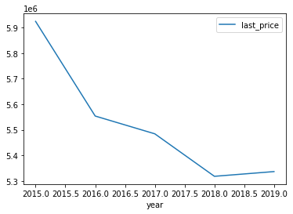

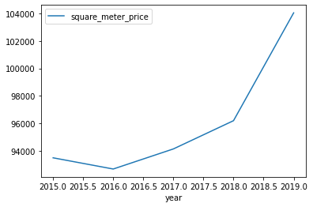

```python
data.loc[data['year'] < 2015 , 'year'] =  None
data=data.dropna(subset=['year'])
data.pivot_table(index='year', values='last_price').plot()
data.pivot_table(index='year', values='square_meter_price').plot()
```

Графики довольно неоднозначные. Общая стоимость выставленных на продажу квартир падает, в то время как цена за квадратный метр растет. Напрашивается вывод, что общая площадь продающихся квартир уменьшается с каждым годом. Проверим эту гипотезу.

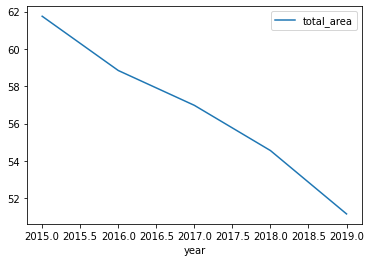

```python
data.pivot_table(index='year', values='total_area').plot()
```

Теперь посчитаем среднюю цену одного квадратного метра в 10 населённых пунктах с наибольшим числом объявлений.

```python
data.groupby(['locality_only_name'])['locality_only_name'].count().sort_values(ascending=False).head(10)
```

```
locality_only_name
Санкт-Петербург    11566
Мурино               433
Шушары               363
Кудрово              349
Всеволожск           295
Колпино              285
Парголово            261
Пушкин               259
Гатчина              243
Петергоф             159
Name: locality_only_name, dtype: int64
```

```python
top_10_series=pd.Series(['Санкт-Петербург' , 'Мурино', 'Шушары', 'Кудрово', 'Всеволожск', 'Колпино', 'Парголово', 'Пушкин', 'Гатчина', 'Петергоф'])
data_top_10 = data.query('locality_only_name in @top_10_series')
```

Сводная таблица с данными по 10 населённым пунктам с наибольшим числом объявлений.

```python
data_suquare_mean = data_top_10.pivot_table(index='locality_only_name', values='square_meter_price', aggfunc=['mean', 'median'])
data_suquare_mean.sort_values(by=('mean','square_meter_price'), ascending=False)
```

| locality_only_name | mean square_meter_price | median square_meter_price |
| --- | --- | --- |
| Санкт-Петербург | 107781.199802 | 102256.034537 |
| Пушкин | 101726.119105 | 97625.329815 |
| Кудрово | 94570.718425 | 95052.083333 |
| Парголово | 89920.430160 | 91642.857143 |
| Мурино | 86116.695239 | 86351.351351 |
| Петергоф | 82287.160784 | 80745.341615 |
| Шушары | 78145.675758 | 76666.666667 |
| Колпино | 74448.476030 | 73529.411765 |
| Всеволожск | 69023.235349 | 65789.473684 |
| Гатчина | 67846.385156 | 67173.913043 |

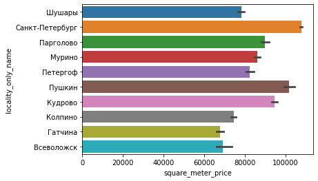

```python
sns.barplot(x='square_meter_price', y='locality_only_name', data=data_top_10)
```

Самая высокая стоимость квадратного метра в Санкт-Петербурге, а самая низкая во Всеволожске и Гатчине (в зависимости от того, ориентируемся мы на среднее или медианное значение.)

```python
data_spb = data.query('locality_only_name=="Санкт-Петербург"')
```

```python
data_spb.pivot_table(index='city_centers_nearest', values='last_price', aggfunc=['median'])
```

| city_centers_nearest | median last_price |
| --- | --- |
| 0.0 | 9590000.0 |
| 1.0 | 9975000.0 |
| 2.0 | 9200000.0 |
| 3.0 | 7550000.0 |
| 4.0 | 8400000.0 |
| 5.0 | 8400000.0 |
| 6.0 | 7500000.0 |
| 7.0 | 6800000.0 |
| 8.0 | 6850000.0 |
| 9.0 | 5200000.0 |
| 10.0 | 4850000.0 |
| 11.0 | 4850000.0 |
| 12.0 | 4900000.0 |
| 13.0 | 5099000.0 |
| 14.0 | 4700000.0 |
| 15.0 | 4700000.0 |
| 16.0 | 4600000.0 |
| 17.0 | 4500000.0 |
| 18.0 | 4200000.0 |
| 19.0 | 4300000.0 |
| 20.0 | 5250000.0 |
| 21.0 | 4771000.0 |
| 22.0 | 4585000.0 |
| 23.0 | 4330000.0 |
| 24.0 | 3540000.0 |
| 25.0 | 4085000.0 |
| 26.0 | 3340000.0 |
| 27.0 | 8300000.0 |
| 28.0 | 4990000.0 |
| 29.0 | 4700000.0 |

В данной таблице показана средняя цена каждого километра. Единственное выбивающееся из обще картины значение -- средняя цена квартир в 27 км от центра больше, чем средняя цена квартир в 6 км от центра. Логично предположить, что таких квартир немного и одна или несколько из них продаются по высокой цене, что может говорить о том, что квартира находится в элитном доме. Проверим эту гипотезу:

```python
data_spb.query('city_centers_nearest == 27')
```

|  | index | total_images | last_price | total_area | first_day_exposition | rooms | ceiling_height | floors_total | living_area | floor | is_apartment | studio | open_plan | kitchen_area | balcony | locality_name | airports_nearest | city_centers_nearest | parks_around3000 | parks_nearest | ponds_around3000 | ponds_nearest | days_exposition | locality_only_name | square_meter_price | weekday | month | year | floor_type |
| --- | --- | --- | --- | --- | --- | --- | --- | --- | --- | --- | --- | --- | --- | --- | --- | --- | --- | --- | --- | --- | --- | --- | --- | --- | --- | --- | --- | --- | --- |
| 557 | 579 | 13 | 14350000.0 | 74.0 | 2017-11-28 | 2.0 | 3.13 | 5.0 | 30.0 | 3 | False | False | False | 25.0 | 0.0 | Санкт-Петербург | 23888.0 | 27.0 | 1.0 | 1496.0 | 0.0 | 510.0 | 128.0 | Санкт-Петербург | 193918.918919 | 1 | 11 | 2017.0 | другой |
| 4360 | 4518 | 6 | 2250000.0 | 32.0 | 2018-02-27 | 1.0 | 2.65 | 2.0 | 16.5 | 2 | False | False | False | 7.0 | 0.0 | Санкт-Петербург | 24006.0 | 27.0 | 0.0 | 459.0 | 0.0 | 510.0 | 178.0 | Санкт-Петербург | 70312.500000 | 1 | 2 | 2018.0 | последний |

Такая квартира действительно всего одна, и, судя по высоте потолков, квартира действительно располагается в нестандартном доме, оставим эти данные, но будем иметь ввиду эту аномалию.

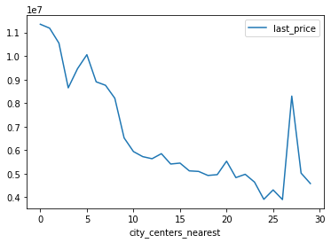

```python
data_spb.pivot_table(index='city_centers_nearest', values='last_price').plot()
```

Видно, что расстояние от центра сильно влияет на цену для квартир, располагающихся на расстоянии примерно 8 км, на бОльшем расстоянии все еще заметно влияние данного параметра, но уже в меньшей степени.

### Общий вывод

#### Пропуски

Все пустые значения, замена которых не повлияет на дальнейший анализ заполнены наиболее подходящими значениями:

- Балконы: т.к. скорее всего, пропуски в этом столбце обусловлены отсутствием балконов, все пропуски были заменены на 0.
- Аналогичная ситуация со стоблцами 'parks_around3000' и 'ponds_around3000'.
- Площадь кухни: так как в таблице есть квартиры студии, в которых нет кухни, все значения в столбце 'kitchen_area' для таких квартир были заменены на 0.
- По одному и тому же принципу были заполнены пустые строки в столбцах 'floors_total', 'ponds_nearest', 'parks_nearest', 'cityCenters_nearest', 'airports_nearest': они были заменены медианными значениями для населенных пунктов, в которых находятся.
  - Для столбца 'floors_total': также было добавлено условие: если средняя высота домов в этом населенном пункте меньше этажа, на котором расположена квартира, принимаем текущий этаж за последний.
  - Для парков и прудов: если по населенному пункту не удалось заполнить пропуск, предполагаем, что парков и прудов поблизости нет, заполняем значением 3100 (так как иначе парк или пруд попал бы в столбец 'ponds_around3000' или 'parks_around3000')
  - Для расстояния от центра: оставшиеся после обработки по медианному значению пропуски были заменены на значение, немного привышающее максимальное, так как логично предположить, что этот параметр пропущен в случае, если город слишком далеко от Санкт-Петербурга.
  - Для расстояния от аэропорта: максимальное расстояние до аэропорта--84869м, логично предположить, что для оставшихся локаций расстояние до аэропорта не указано, т.к. аэпорот слишком далеко, поэтому оставшиеся значения были заменены на 200000, т.к. судя по картам, это максимальное расстояние от этих локаций до аэропорта: около 200 км расстояние между Каменногорском или Кузнечным (самыми северными городами Лен. области) и Пулково.
- Пропуски в столбце с высотой потолка были заменены на медианное значение.

#### Обработка аномальных и редких значений

В этом разделе были обработаны аномальные и редкие значения, а также были отброшены редкие значения, которые могли повлиять на дальнейший анализ и/или затрудняли чтение графиков.

- **Столбец locality_name**: был добавлен новый столбец, в котором из названий населенных пунктов были убраны типы населенных пунктов (поселок/деревня/товарищество и т.д.). Это облегчает группировку по данному параметру в дальшейшем.
- **Столбец ceiling_height**: в списке уникальных значений присутствовали явные выбросы (14, 25, 32 метра). Со значениями 20-35м логично будет заменить эти значения на 2.0-3.5.

#### Дополнительные значения

Были добавлены дополнительные столбцы для более углубленного анализа со следующими значениями:

- цена одного квадратного метра;
- день недели публикации объявления (0 — понедельник, 1 — вторник и так далее);
- месяц публикации объявления;
- год публикации объявления;
- тип этажа квартиры (значения — «первый», «последний», «другой»);
- расстояние до центра города в километрах (был заменен оригинальных столбец с расстоянием в метрах, т.к. эти данные не пригодятся в дальнейшем).
- **Столбец square_meter_price**: в данном столбце так же было замечено аномальное значение: квартира с ценой 111 рублей за квадратный метр.

#### Результат предобработки

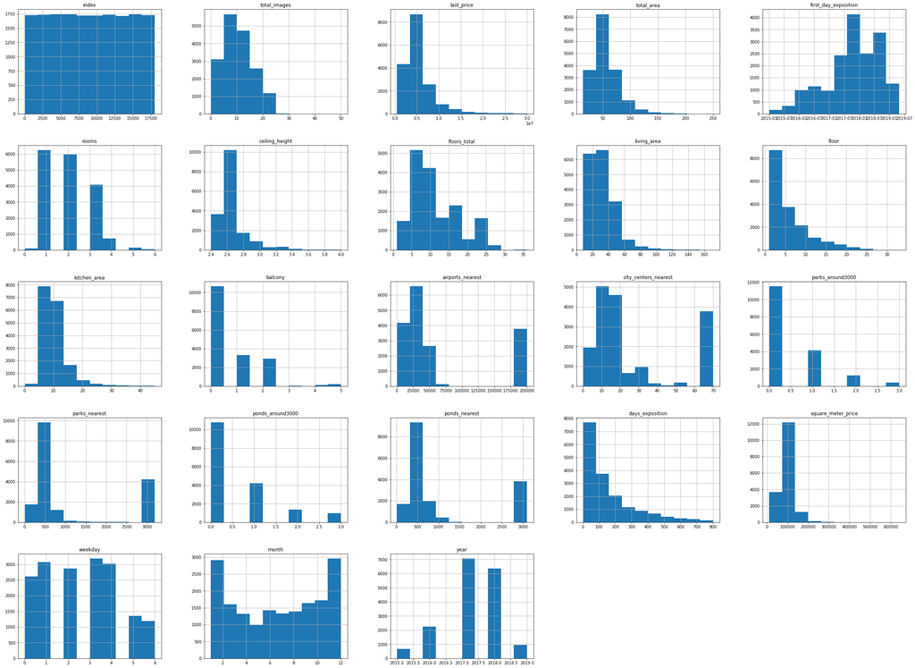

*Заметны искуственно добавленные значения, но они были оставлены, при построении графиков в дальнейшем я ограничивала их размер, чтобы это не мешало чтению*

#### Исследовательский анализ

##### В результате исследования отдельных параметров были замечены следующие интересные особенности:

1. Объявления реже выставляют в выходные дни и в месяцы, когда чаще берут отпуск либо в месяцы с длительными государственными праздниками. Скорее всего, это связано с тем, что большинство квартир выставляют риэлторы, которые в выходные занимаются скорее выездами и показами квартир, берут отпуск летом и отдыхают на новогодние и майские праздники.
2. Продажа обычно занимает около 100 дней. Продажа менее, чем за 50 дней можно назвать быстрыми, а продажи более, чем за 200 дней--напротив, необычно долгими.

##### Факторы, влияющие на общую стоимость квартиры:

1. *Общая площадь, жилая площадь и площадь кухни:*

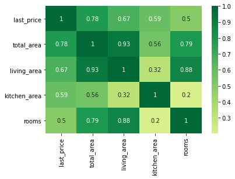

По таблице корреляции можно увидеть, что самая очевидная зависимость прослеживается между общей площадью и ценой, видна сильная (больше 0.7) положительная линейная корелляция. Точки выстраиваются вокруг линии наилучшего соответствия, что позволяет говорить о прямой зависимости.

1. **_*Количество комнат:***

Для большей наглядности, приведу 2 графика:

- На данном графике в целом прослеживается тенденция "чем больше комнат, тем дороже будет стоить квартира", но цена на студии как будто бы начинается с большего значения, чем цена на одно- и двухкомнатные квартиры.

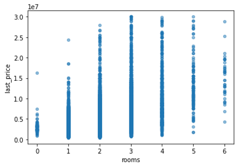

- Поэтому был построен график зависимости стоимости от общей площади И количества комнат, по которому можно заметить, что количество комнат в меньшей степени влияет на общую стоимость для квартир с 4 и больше комнатами:

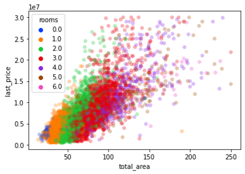

1. *Тип этажа:*

Квартиры на первом этаже обычно стоят дешевле.

1. *Дата размещения объявления:*
   - *День недели:*

     Средняя стоимость квартир, выставленных на продажу в четверг значительно превышает среднюю стоимость квартир, выставленных на продажу в любой другой день. Для выходных ситуация обратная--выставленные на продажу в эти дни квартиры в среднем дешевле, чем остальные. Однако, стоит обратить внимание, что разница между максимальным значением (четверг) и минимальным значением (воскресенье) составляет 300 000 рублей, а это примерно 5,4%.
   - *Месяц:*

     С месяцами ситуация похожая: в сентябре цены на квартиры в среднем значительно выше, чем в другие месяцы, а в марте и октябре -- наоборот. Разница между максимальным и минимальным значениями всё ещё небольшая: 350 000 рублей или 6,2%.
   - *Год:*

     В ситуации с годом продажи, графики довольно неоднозначные. Общая стоимость выставленных на продажу квартир падает:

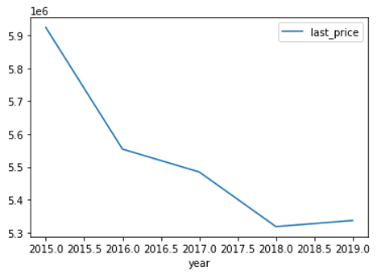

[output not shown]

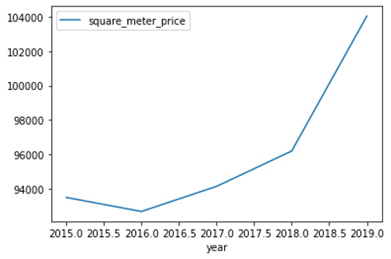

[output not shown]

##### Cредняя цена одного квадратного метра в 10 населённых пунктах с наибольшим числом объявлений:

Городом с самой высокой ценой за квадратный метр оказался Санкт-Петебрург, а городами с самой низкой ценой -- Всеволожск и Гатчина (в зависимости от того, ориентируемся ли мы на среднюю или медианную стоимость.

| Город | Средняя цена | Медианная цена |
| --- | --- | --- |
| Санкт-Петербург | 107781.199802 | 102256.034537 |
| Всеволожск | 69023.235349 | 65789.473684 |
| Гатчина | 67846.385156 | 67173.913043 |

#### Зависимость стоимости объектов от расстояния до центра города:

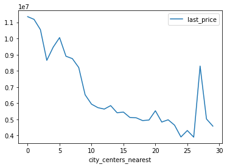

Видно, что расстояние от центра города в значительной степени влияет на стоимость квартир, когда оно меньше 8 км, чем дальше от центра располагается квартира, тем менее значителен этот показатель.

Аномальный скачок на 27 километре обусловлен наличием в базе всего двух квартир, расположенных на этом расстоянии. Цена одной из них очень высока, что, судя по высоте потолков в этой квартире, может быть связано с тем, что квартира располагается в элитном доме.